# Practical_Machine_Learning

Saurabh Gombar

February 13, 2017

### Assignment Summary

The goal of the assignment is to use machine learning to predict how well a user doing an exercise. The “classe” holds the true outcome with the remaining features used to predict the outcome. Some of the features need to be removed because they are indeices, times, or other variables that are meta data instead of data related to the actual exercise. We will use a CART model for our prediction and accuracy in a cross validation set as a surrogate out of sample error.

### Load Essential Libraries

```r
  library(ggplot2)
  library(caret)
  library(rattle)
```

### Read training and test data

Partition the training set into training and cross-validation. The testData will be used only after the model is trained and validated (not to mention it doesn’t have the classe variable anyway!).

```r
set.seed(1000)
trainDat <- read.csv(url("https://d396qusza40orc.cloudfront.net/predmachlearn/pml-training.csv"), na.strings=c("NA","#DIV/0!",""))
testDat <- read.csv(url("https://d396qusza40orc.cloudfront.net/predmachlearn/pml-testing.csv"), na.strings=c("NA","#DIV/0!",""))

dataSplit <- createDataPartition(y=trainDat$classe, p=0.7, list=FALSE )
training <- trainDat[dataSplit,]
crossValid <- trainDat[-dataSplit,]
```

### Feature Selection

We want to remove features that are unlikely to improve predictions and instead just going to increase the overall variance of the model. To do this ware going to: A) remove the features with near zero variance B) Remove the features where >95% of the values are NA C) Remove the features that are meta data instead of data from the activity iteslf (indices, time-stamps, users, etc…the first 6 after cleaning.

```r
omitCols <- nearZeroVar(training)

training_clean <- training[-omitCols]
crossValid_clean <- crossValid[-omitCols]
testDat_clean <- testDat[-omitCols]

hiNAList <- sapply(as.data.frame(sapply(training_clean, is.na)), sum)/length(training_clean[,1])
colToKeep <- as.logical(hiNAList < 0.95)
training_clean = training_clean[colToKeep]
crossValid_clean = crossValid_clean[colToKeep]
testDat_clean = testDat_clean[colToKeep]

training_clean = training_clean[-c(1:6)]
crossValid_clean = crossValid_clean[-c(1:6)]
testDat_clean = testDat_clean[-c(1:6)]
```

### Machine learning

Now we learn on the training data and check against the cross validation set get a sense of accuracy for our model. Since this is a classificaiton problem we are going to use Recursive Partitioning and regression tree. The decision tree is higlighted in the provided figure. The accuracy obtained from our confusion matrix is a measure of our out of sample error.

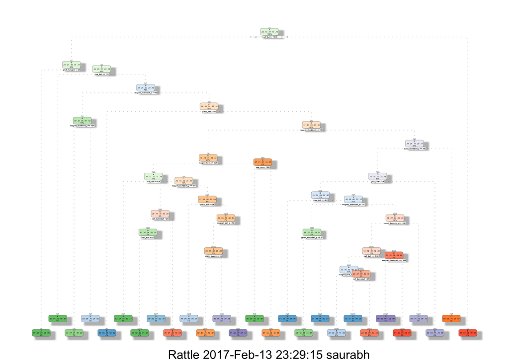

```r
  ForestTrain <- rpart(classe ~ ., training_clean, method="class")
  fancyRpartPlot(ForestTrain)
```

```r
  confusionMatrix(predict(ForestTrain, crossValid_clean, type="class"), crossValid$classe)
```

```
## Confusion Matrix and Statistics
##
##           Reference
## Prediction    A    B    C    D    E
##          A 1461  150   10   57   50
##          B   88  814  138   68   71
##          C   14  111  790  161   83
##          D   44   56   47  643   82
##          E   67    8   41   35  796
##
## Overall Statistics
##
##                Accuracy : 0.7653
##                  95% CI : (0.7543, 0.7761)
##     No Information Rate : 0.2845
##     P-Value [Acc > NIR] : < 2.2e-16
##
##                   Kappa : 0.7028
##  Mcnemar's Test P-Value : < 2.2e-16
##
## Statistics by Class:
##
##                      Class: A Class: B Class: C Class: D Class: E
## Sensitivity            0.8728   0.7147   0.7700   0.6670   0.7357
## Specificity            0.9366   0.9231   0.9241   0.9535   0.9686
## Pos Pred Value         0.8455   0.6904   0.6816   0.7374   0.8405
## Neg Pred Value         0.9488   0.9309   0.9501   0.9360   0.9421
## Prevalence             0.2845   0.1935   0.1743   0.1638   0.1839
## Detection Rate         0.2483   0.1383   0.1342   0.1093   0.1353
## Detection Prevalence   0.2936   0.2003   0.1969   0.1482   0.1609
## Balanced Accuracy      0.9047   0.8189   0.8470   0.8102   0.8521
```

### Prediction of Unkowns

Finally we want to predict the 20 cases from the test data provided. They don’t give us the classe so we don’t know how we did!

```r
predict(ForestTrain, testDat_clean, type="class")
```

```
##  1  2  3  4  5  6  7  8  9 10 11 12 13 14 15 16 17 18 19 20
##  B  A  B  A  A  C  D  D  A  A  C  B  B  A  E  E  A  B  B  B
## Levels: A B C D E
```